# Using Raster Data in R

## 13.1 Distance & Direction

### 13.1.1 Distance functions

Attention must be paid to the raster projection as it can noticiably affect the results (small areas often use a UTM projection, while large areas/world oftne use ‘+proj=longlat’). Illustrations of the different results obtained using different projections can be seen in the examples for the functions `pointDistance` and `gridDistance` below.

The units of the distances returned by all distance functions in the package `raster` are:

- *Meters* if the RasterLayer is not projected (i.e. ‘+proj=longlat’)
- *Map units (typically also meters)* if the RasterLayer is projected.

More advanced distance function can be found in other packages, including:

- `gdistance`: Computes Distances and Routes on Geographical Grids. It includes advanced distances, such as: cost distance and resistance distance. See package vignette [here](https://cran.r-project.org/web/packages/gdistance/vignettes/gdistance1.pdf). A tutorial on how to calculate Cummulative Distances usign this package can be found [here](http://personal.colby.edu/personal/m/mgimond/Spatial/Distance_rook_vs_queen_vs_knight.html)
- `geosphere`: Uses spherical trigonometry for geographic applications. It computes great-circle distances (and related measures)for angular (i.e. spherical longitude/latitude coordinates) locations. See package vignette [here](https://cran.r-project.org/web/packages/geosphere/vignettes/geosphere.pdf)

`distance`: Computes the distance from all NA cells to cells that are not NA.

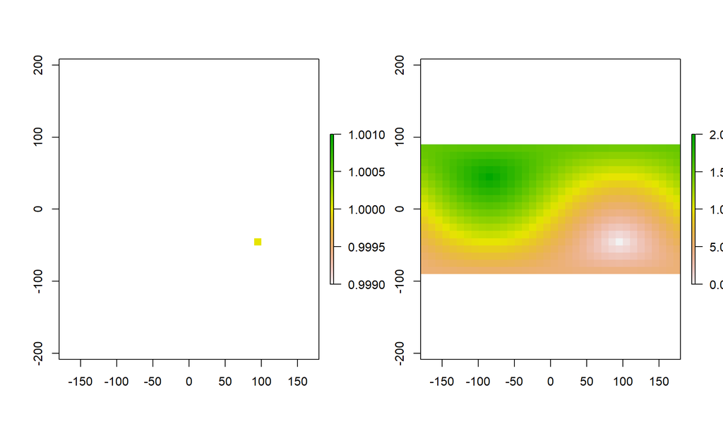

```r
# Create and Fill raster with values (all cells = NA, but one 'half-way' in the Souther hemisphere
r = raster(ncol=18*2,nrow=9*2) # 1 cell for each 10x10 degrees
r[] = NA
r[cellFromXY(r, cbind(90,-45))] = 1

# Compute distances. NOTE: Using a representation of 'Earth` (i.e. ~ Spheric), so Distances first increase and they decrease.
r.dists = distance(r)

# Plot rasters
par(mfrow=c(1,2))
plot(r)
plot(r.dists)
```

`distanceFromPoints`: Computes the distance from a set of points to all cells of a Raster* object.

```r
# Distance from 1 point
# =====================
 # Projection = 'longlat'
 # ----------------------
r = raster(ncol=18*2,nrow=9*2) # 1 cell for each 10x10 degrees
point1.xy = c(90,-45)
d.point1.longlat = distanceFromPoints(r, point1.xy)
d.point1.longlat
```

```
## class       : RasterLayer
## dimensions  : 18, 36, 648  (nrow, ncol, ncell)
## resolution  : 10, 10  (x, y)
## extent      : -180, 180, -90, 90  (xmin, xmax, ymin, ymax)
## coord. ref. : +proj=longlat +datum=WGS84 +ellps=WGS84 +towgs84=0,0,0
## data source : in memory
## names       : layer
## values      : 394171.6, 19626586  (min, max)
```

```r
 # Projection = 'utm'
 # ------------------
crs(r) = '+proj=utm +zone12 +datum=WGS84' # Change projection
d.point1 = distanceFromPoints(r, point1.xy)
d.point1.utm = distanceFromPoints(r, point1.xy)
d.point1.utm
```

```
## class       : RasterLayer
## dimensions  : 18, 36, 648  (nrow, ncol, ncell)
## resolution  : 10, 10  (x, y)
## extent      : -180, 180, -90, 90  (xmin, xmax, ymin, ymax)
## coord. ref. : +proj=utm +datum=WGS84 +ellps=WGS84 +towgs84=0,0,0
## data source : in memory
## names       : layer
## values      : 5, 295.1694  (min, max)
```

```r
# Distance from 2 points
# ======================
 # Projection = 'longlat'
 # ----------------------
r = raster(ncol=18*2,nrow=9*2) # 1 cell for each 10x10 degrees
points2n3.xy = cbind(c(0,90),c(0,-45))
d.points2n3.longlat = distanceFromPoints(r, points2n3.xy)
d.points2n3.longlat
```

```
## class       : RasterLayer
## dimensions  : 18, 36, 648  (nrow, ncol, ncell)
## resolution  : 10, 10  (x, y)
## extent      : -180, 180, -90, 90  (xmin, xmax, ymin, ymax)
## coord. ref. : +proj=longlat +datum=WGS84 +ellps=WGS84 +towgs84=0,0,0
## data source : in memory
## names       : layer
## values      : 394171.6, 14705105  (min, max)
```

```r
 # Projection = 'utm'
 # ------------------
crs(r) = '+proj=utm +zone12 + datum=WGS84' # Change projection
d.points2n3.utm = distanceFromPoints(r, points2n3.xy)
d.points2n3.utm
```

```
## class       : RasterLayer
## dimensions  : 18, 36, 648  (nrow, ncol, ncell)
## resolution  : 10, 10  (x, y)
## extent      : -180, 180, -90, 90  (xmin, xmax, ymin, ymax)
## coord. ref. : +proj=utm +ellps=WGS84
## data source : in memory
## names       : layer
## values      : 5, 194.5508  (min, max)
```

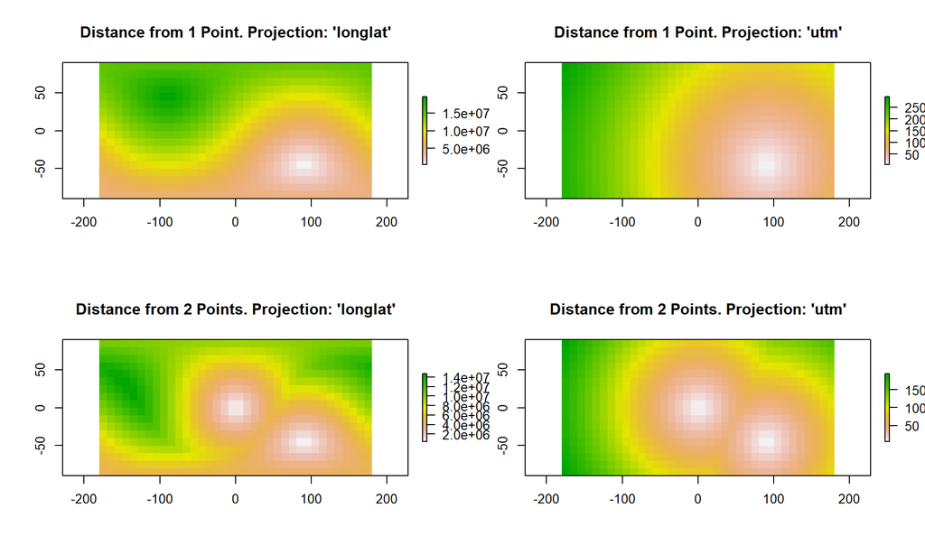

```r
# Plot Distances
# ==============
par(mfrow=c(2,2))
plot(d.point1.longlat, main="Distance from 1 Point. Projection: 'longlat'")
plot(d.point1.utm, main="Distance from 1 Point. Projection: 'utm'")
plot(d.points2n3.longlat, main="Distance from 2 Points. Projection: 'longlat'")
plot(d.points2n3.utm, main="Distance from 2 Points. Projection: 'utm'")
```

`pointDistance`: Computes the shortest geographic distance between two (set of) points. When sets of points are given, if both sets have:

- *Equal number of points*: The distance between each point and the corresponding point in the other set is calculated, except if the argument allpairs is TRUE (i.e. `allpairs=TRUE`).
- *Different number of points*: The distance between each possible pair of points among sets is calculated.

Argument `lonlat`: Logical. If:

- TRUE: Coordinates should be in degrees. The distance is calculated on the World Geodetic System (WGS) ellipsoid. The units of the calculated distances are meters.
- FALSE: Coordinates represent Euclidian space (e.g. units of meters). The distance is calculate d on a plane. The units of the calculated distances are map units (often also meters).

```r
# Create Sets of Points
points.set1 = cbind(c(30,60,90),c(15,30,45))
points.set2 = cbind(c(120,150,180),c(60,75,90))
points.set3 = cbind(c(120,180),c(60, 90))
points.set1; points.set2; points.set3
```

```
##      [,1] [,2]
## [1,]   30   15
## [2,]   60   30
## [3,]   90   45
```

```
##      [,1] [,2]
## [1,]  120   60
## [2,]  150   75
## [3,]  180   90
```

```
##      [,1] [,2]
## [1,]  120   60
## [2,]  180   90
```

```r
# Calculate Distances
  # Between Points
pointDistance(c(0,0), c(10,10), longlat=TRUE)   # Distances on WGS ellipsoid
```

```
## [1] 1565109
```

```r
pointDistance(c(0,0), c(10,10), longlat=FALSE)   # Distances on a plane
```

```
## [1] 14.14214
```

```r
sqrt(10^2+10^2)  # Distances on a plane are the Euclidian Distances
```

```
## [1] 14.14214
```

```r
  # Between a Point and a Set of Points: Calculate all possible pairs (here 3 pairs)
pointDistance(c(0,0), points.set2, longlat=TRUE)   # Distances on WGS ellipsoid
```

```
## [1] 11621024 11448656 10001966
```

```r
pointDistance(c(0,0), points.set2, longlat=FALSE)   # Distances on a plane
```

```
## [1] 134.1641 167.7051 201.2461
```

```r
  # Between two Sets of Points with equal number of points: Calculate distances single pairs of points across both sets
pointDistance(points.set1, points.set2, longlat=TRUE)   # Distances on WGS ellipsoid: All results different
```

```
## [1] 8574772 6807739 5017021
```

```r
pointDistance(points.set1, points.set2, longlat=FALSE)   # Distances on a plane: All results equal
```

```
## [1] 100.6231 100.6231 100.6231
```

```r
   # Between two Sets of Points with different number of points: Calculate distances all possible pairs across both sets
pointDistance(points.set1, points.set3, longlat=TRUE)   # Distances on WGS ellipsoid
```

```
##         [,1]    [,2]
## [1,] 8574772 8342976
## [2,] 5511860 6681852
## [3,] 2594667 5017021
```

```r
pointDistance(points.set1, points.set3, longlat=FALSE)   # Distances on a plane
```

```
##           [,1]     [,2]
## [1,] 100.62306 167.7051
## [2,]  67.08204 134.1641
## [3,]  33.54102 100.6231
```

`gridDistance`: Computes the distance from a cell or set of cells to cells in a RasterLayer. The distances are computed by summing the local distances between the center of the cells. The path can follow any of the 8 neighboring cells (i.e. the ‘queen’ case, which is currently the only one implemented). It can be specified that certain types of cells (i.e. with a given value) cannot be traversed by the path. For example, water bodies can be excluded by providing the cell value representing them.

If the RasterLayer to be processed is big, it will be processed in chunks. This may lead to errors when of complex objects spread over different chunks (e.g. meandering rivers). Varying the chunk size might help solving these issues (see function `setOptions`).

Important arguments:

- `x`: A RasterLayer
- `origin``: Value(s) of the cell(s) from which the distance is calculated
- `omit`: Value(s) of the cell(s) that cannot be traversed.

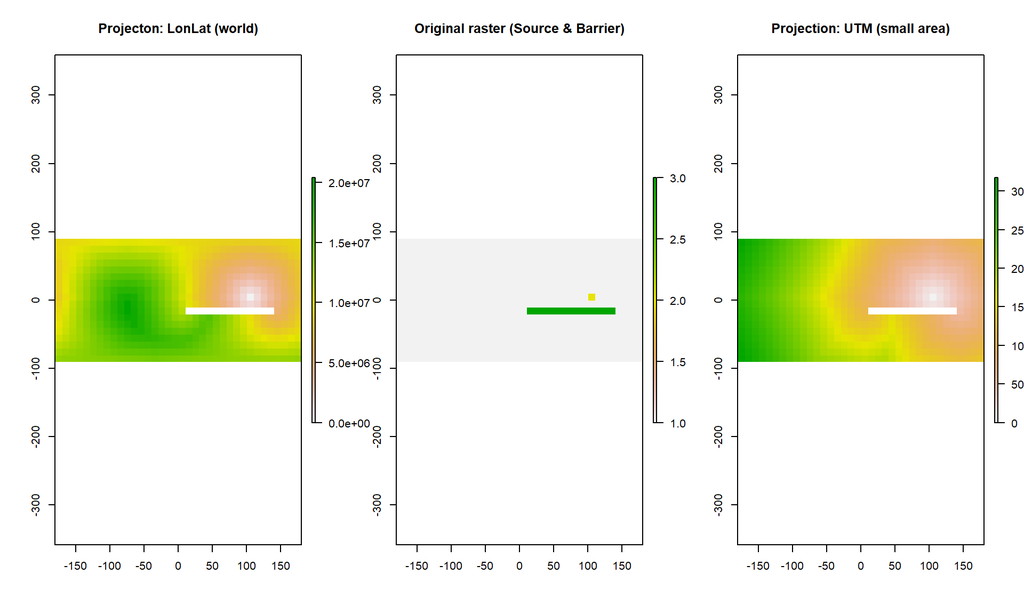

```r
# Projection: 'lonlat' (world)
# ----------------------------
r = raster(ncol=18*2,nrow=9*2) # 1 cell for each 10x10 degrees
r[] = 1
r[317] = 2
r[380:392] = 3
dist.lonlat = gridDistance(r,origin=2,omit=3)

# Projection: 'utm' (small area)
# ------------------------------
projection(r) = "+proj=utm +zone=15 +ellps=GRS80 +datum=NAD83 +units=m +no_defs"
dist.utm = gridDistance(r,origin=2,omit=3)

# Plot results
# ------------
par(mfrow=c(1,3))
plot(dist.lonlat, main="Projecton: LonLat (world)")
plot(r, main="Original raster (Source & Barrier)")
plot(dist.utm, main="Projection: UTM (small area)")
```

### 13.1.2 Direction functions

`direction`: Computes the direction (azimuth) toward (or from) the nearest cell that is not NA. Important arguments:

- ‘from’:
  - FALSE (default): Computes the direction to the nearest cell that is not NA.
  - TRUE: Computes the direction from the nearest cell that is not NA.
- `degrees`:
  - FALSE (default): Computes the direction in radians (i.e. unit of direction: radians).
  - TRUE: Computes the direction in degrees (i.e. unit of direction: degrees).

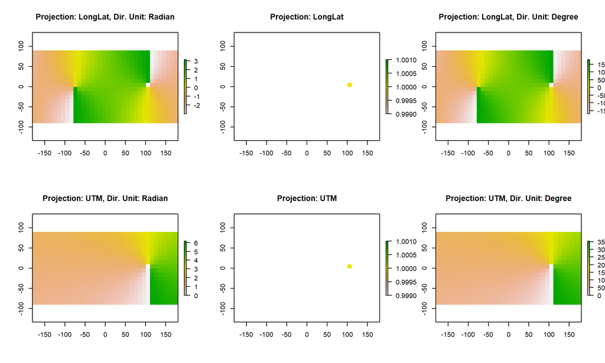

```r
# Projection: LongLat
r.longlat = raster(ncol=18*2,nrow=9*2) # 1 cell for each 10x10 degrees
r.longlat[] = NA
r.longlat[317] = 1
dir.longlat.rad = direction(r.longlat)  # Computes Direction in Radians
dir.longlat.deg = direction(r.longlat, degrees=TRUE) # Computes Direction in Degrees

# Projection: UTM
r.utm = r.longlat
projection(r.utm) = "+proj=utm +zone=15 +ellps=GRS80 +datum=NAD83 +units=m +no_defs"
dir.utm.rad = direction(r.utm)  # Computes Direction in Radians
dir.utm.deg = direction(r.utm, degrees=TRUE) # Computes Direction in Degrees

# Plot results
par(mfrow=c(2,3))
plot(dir.longlat.rad, main="Projection: LongLat, Dir. Unit: Radian")
plot(r.longlat, main="Projection: LongLat")
plot(dir.longlat.deg, main="Projection: LongLat, Dir. Unit: Degree")
plot(dir.utm.rad, main="Projection: UTM, Dir. Unit: Radian")
plot(r.utm, main="Projection: UTM")
plot(dir.utm.deg, main="Projection: UTM, Dir. Unit: Degree")
```

## 13.2 Spatial autocorrelation Raster

To compute measures of autocorrelation in a RasterLayer, two autocorrelation measures are available: Moran’s I and Geary’s C.Both can be computed: Globally (returns a number) or Locally (returns a RasterLayer object). They use weights defined by a matrix, as in ‘focal’ (see above ‘Summarizing values in a “moving window”’). The Weights Shape and Size can be changed. The default is: ‘w=matrix(c(1,1,1,1,0,1,1,1,1), 3,3)’; i.e. a 3x3 matrix.

```r
# Global autocorrelation
Moran(r2b.elev)
```

```
## [1] 0.6084339
```

```r
Moran(r2b.elev, w=matrix(c(rep(1,12),0,rep(1,12)), nrow=5))
```

```
## [1] 0.5514688
```

```r
Geary(r2b.elev)
```

```
## [1] 0.3075339
```

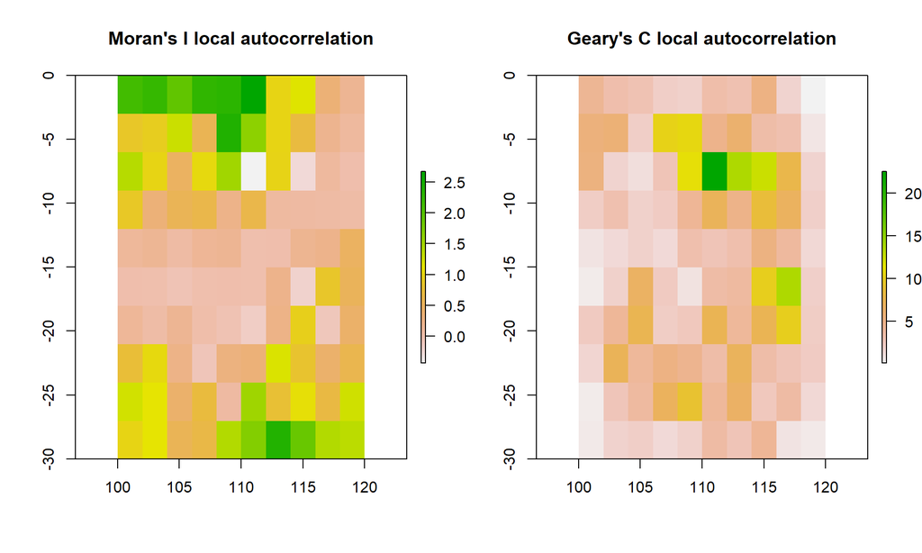

```r
# Local autocorrelation
par(mfrow=c(1,2))
plot(MoranLocal(r2b.elev), main="Moran's I local autocorrelation" )
plot(GearyLocal(r2b.elev), main="Geary's C local autocorrelation"  )
```

## 13.3 Elevation, slope, aspect

Slope & aspect can be computed with function `terrain`.

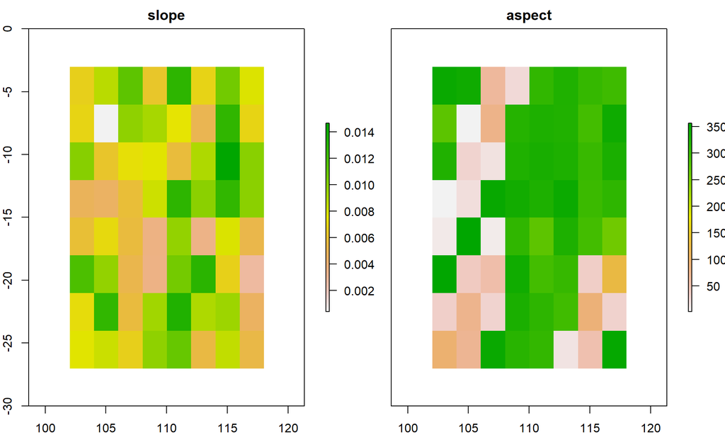

```r
# Basic maps
r2b.slo.asp.deg.ras = terrain(r2b.elev, opt = c("slope", "aspect"), unit = "degrees")
#plot(r2b.elev)
plot(r2b.slo.asp.deg.ras)
```

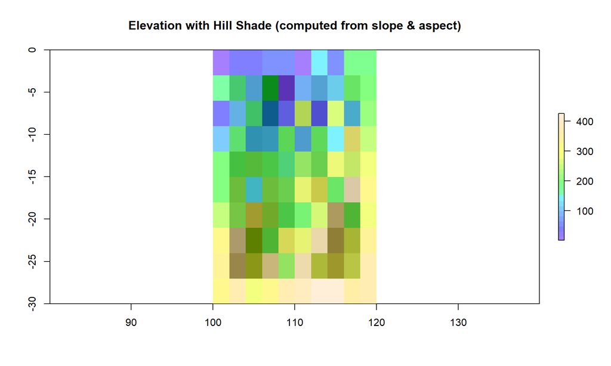

```r
# Compute: Slope & Aspect
r2b.slope = terrain(r2b.elev, opt = "Slope")
r2b.aspect = terrain(r2b.elev, opt = "Aspect")

# Nicer plot
  # Compute hill shade from Slope and Aspect layers (both in radians).
r2b.hillShade = hillShade(r2b.slope, r2b.aspect, 40, 270)
  # Plot Hill Shade layer as a backdrop and then Elevation on top as a semi-transparent layer.
plot(r2b.hillShade, col = grey(0:100/100), legend = FALSE, main="Elevation with Hill Shade (computed from slope & aspect)")
plot(r2b.elev, col = topo.colors(25, alpha = 0.5), add = TRUE) # 'alpha': Transparency channel, range=[0,1] (0=transparent, 1=opaque)
```

# 14 THE END